# Transpose_K-means_PAM

Cassandra Sperow

2023-10-09

## Transpose the Data Matrix to Attempt Better Results from K-Means and PAM

- Bacteria are what we’re trying to cluster
- Transpose to where the bacteria ASVs are the rows instead of the columns

### Read in proportion-based bacteria data

```r
# read in the new proportion-based bacteria data
read_csv("../output/rev_bacteria_prop_df.csv") -> rev_bacteria_prop_df
head(rev_bacteria_prop_df)
```

```
## # A tibble: 6 × 5,890
##   sample_id ASV0001 ASV0002 ASV0003 ASV0004 ASV0005 ASV0006 ASV0007 ASV0008
##   <chr>       <dbl>   <dbl>   <dbl>   <dbl>   <dbl>   <dbl>   <dbl>   <dbl>
## 1 SMAQ-R1-1  0.188        0 0       0.00319  0.0870  0.0618  0.0518       0
## 2 SMAQ-R1-2  0.0522       0 0       0.0206   0.196   0.132   0.0170       0
## 3 SMAQ-R1-3  0.0292       0 0.00126 0.00883  0.246   0.158   0.0101       0
## 4 SMAQ-R1-4  0.213        0 0       0.00487  0.121   0.0743  0.0678       0
## 5 SMAQ-R1-5  0.123        0 0       0.0153   0.235   0.116   0.0361       0
## 6 SMAQ-R1-6  0.415        0 0       0.00686  0.0305  0.0167  0.118        0
## # ℹ 5,881 more variables: ASV0009 <dbl>, ASV0010 <dbl>, ASV0011 <dbl>,
## #   ASV0012 <dbl>, ASV0013 <dbl>, ASV0014 <dbl>, ASV0015 <dbl>, ASV0016 <dbl>,
## #   ASV0017 <dbl>, ASV0018 <dbl>, ASV0019 <dbl>, ASV0020 <dbl>, ASV0022 <dbl>,
## #   ASV0023 <dbl>, ASV0024 <dbl>, ASV0025 <dbl>, ASV0027 <dbl>, ASV0030 <dbl>,
## #   ASV0031 <dbl>, ASV0032 <dbl>, ASV0033 <dbl>, ASV0034 <dbl>, ASV0035 <dbl>,
## #   ASV0036 <dbl>, ASV0037 <dbl>, ASV0039 <dbl>, ASV0040 <dbl>, ASV0041 <dbl>,
## #   ASV0042 <dbl>, ASV0043 <dbl>, ASV0044 <dbl>, ASV0046 <dbl>, …
```

#### Transpose for Bacteria to be Observations

- This is still using proportions before the call with Dr. C on using CLR or coseq library that does logCLR

```r
rev_bacteria_prop_df %>%
  t() %>%
  as.data.frame() %>%
  janitor::row_to_names(1) %>%
  map(., ~as.numeric(.)) %>%
  as.data.frame() -> t_rev_bac_prop
```

### Review data format

```r
dim(t_rev_bac_prop)
```

```
## [1] 5889  659
```

```r
head(t_rev_bac_prop)
```

```
##   SMAQ.R1.1 SMAQ.R1.2 SMAQ.R1.3 SMAQ.R1.4 SMAQ.R1.5 SMAQ.R1.6 SMAQ.R1.7
## 1   0.18795   0.05223   0.02918   0.21307   0.12339   0.41532   0.38730
## 2   0.00000   0.00000   0.00000   0.00000   0.00000   0.00000   0.00000
## 3   0.00000   0.00000   0.00126   0.00000   0.00000   0.00000   0.00000
## 4   0.00319   0.02063   0.00883   0.00487   0.01530   0.00686   0.00830
## 5   0.08702   0.19616   0.24588   0.12137   0.23547   0.03049   0.03543
## 6   0.06182   0.13213   0.15787   0.07426   0.11554   0.01670   0.01893
##   SMAQ.R1.8 SMAQ.R1.10 SMAQ.R1.11 SMAQ.R1.12 SMAQ.R1.14 SMAQ.R1.15 SMAQ.R1.19
## 1   0.07720    0.12463    0.57571    0.23535    0.35481    0.09180    0.29893
## 2   0.00000    0.00000    0.00000    0.00000    0.00000    0.00000    0.00000
## 3   0.00000    0.00000    0.00000    0.00000    0.00000    0.00000    0.00000
## 4   0.02340    0.01654    0.00000    0.02626    0.00000    0.00915    0.00267
## 5   0.15825    0.07753    0.00616    0.09926    0.00091    0.25285    0.04100
## 6   0.06226    0.05379    0.00525    0.04063    0.00069    0.13183    0.02547
##   SMAQ.R1.23 SMAQ.R1.24 SMAQ.R1.25 SMAQ.R1.28 SMAQ.R1.29 SMAQ.R2.16 SMAQ.R2.33
```

[output cut: 650 more lines]

```r
#glimpse(t_rev_bac_prop)
```

## K-Means

- First run gave warning of not converging in 10 iterations
- Increased max iterations to 50
- Re-run a few times to see if it’s stable

```r
kmeans( scale(t_rev_bac_prop) ,
       centers = 239,  # PCA Results
       iter.max = 50
) -> t_kmeans_out
```

```r
t_kmeans_out$size
```

```
##   [1]    1    3    1    6   21    1    1    4    1    1    7    2    3    1   13
##  [16]    1    2    2    8    3    2    1    1    1    2    1   12    7    1    9
##  [31]    1    1    1    3    2    6    1    1    1    1    4    1    1    3    1
##  [46]    4    1    1    4    3    7    5    1    1    2    1    2   31   11   17
##  [61]    2    1    2    1   40  119    1    1    5    1    1    2    1    1    4
##  [76]    2    1    1    1    1    1    1   10   30    1    3    1    7   12    1
##  [91]    3    1    3    6    1    1    7    4    1    2   93    1    4    3   18
## [106]    1    1    8    1    3    1    6    1    1    1    1   27    4    2    2
## [121]    1    1    1    2   10    1   16    2    4    1    4    1   23   45    2
## [136]    1    2    3   18    6    1    5    2    2    1    2    1    1   45    2
## [151]    1    1    1    2    1    2    8    7    1   31    1    1    1    2    4
## [166]    2    4    1    1    1    1    1    1    1    1    2    2    5    2    1
## [181]    4    2    2    2   23    2    3    2    1   20    1    1    1    1    1
## [196]    4    1    1    1    3    1    2    2    3    3    1    1    1    1    1
## [211]    1    1   19    2    2    1    1    1   67    1    1    2    2    2    1
## [226]    1    2    1    1    1    4    1    4    1    1    2 4675    1    1
```

```r
kmeans( scale(t_rev_bac_prop) ,
       centers = 239,  # PCA Results
       iter.max = 50
) -> t_kmeans_out_2


t_kmeans_out_2$size
```

```
##   [1]    5    7    2    1    2    1    2    2   22    2    1    1    1    1    8
##  [16]    2    1    7    1    2    1    2    3    1    1    5    4    1    2    2
##  [31]   14    1    1    7    2    1    1    1    4   13    1    3   42   24    3
##  [46]    1   45    1    2    1   44    3    1    1    1    4    6    1    1    4
##  [61]    6    2   11    2    1    1    4    7    1    2    2    1    1    1    1
##  [76]    2    2    2    4    1    6    2    5    2    1    2    1    3   29   18
##  [91]    2    1    1    1    1    1    1   20   31    1    2 4660    1    5    2
## [106]    8    4    1    3    1    1    4    2    1    2    1    1    2    2    1
## [121]    1    6  112    1    7    3    1    1    1    1    1    1    4    2    3
## [136]    1    1    5   18    1    7    1    4    1    1    2    1    3    1    3
## [151]   43    1    1    1    1    1    4    2    3    2    1    1    2    2    1
## [166]    3   23    1    1    2    2    2    1    1    2    1    1    2    1    9
## [181]    3    6    3    1    1    1    1    1   67    1    2    4    2   89    4
## [196]    1    8   26    1    1   40    1    2    1    1    1    1   16    1    2
## [211]    1    3    1    1    3    5   12    2    1    1    1    1    1    5    6
## [226]    1    1    1    6    1    1    3    1    1    1    1    7    3    1
```

- 3rd time

```r
kmeans( scale(t_rev_bac_prop) ,
       centers = 239,  # PCA Results
       iter.max = 50
) -> t_kmeans_out_3


t_kmeans_out_3$size
```

```
##   [1]   26    1    1    1    1    1    3    1    1    1    1    5    1    1    5
##  [16]    2    6    3    1    1    7    8    6    2    1    1   40   66    3    1
##  [31]    1   20    1   20    7    1    1    1    1    1    2    2    4    1    8
##  [46]    2    1    1    1    4   16    2    1    1    3    4    1    1    1    1
##  [61]    8    2    7    2    2    7    1    8    2    1    1    1    1  124    5
##  [76]   36    1   82    6    4    1    1    2    6    3    4    1    1    4    1
##  [91]    1    4    3    1    1    1    1    2    3    1    1    1    2    1    1
## [106]    3    1    3    1    1    1    2    2    2    1    1    2    5    1    1
## [121]    1    1    1    2    2   47    1    1    5   16    2    7    3    3    1
## [136]   18    1    2    4    1    2    2    2    9    3    1    3   31   17   18
## [151]    1    3    3 4641    1    1    1    1    1    1    1    6    1   42    2
## [166]    2    5    1    2    2    7    2    1    2    1    2    1    1    1    1
## [181]    1    4    2    9    6    1    2    1   10    1    1    1    1    3    3
## [196]    1    2    9    1    1    1    1    1   32    1    4    3    2    1    1
## [211]    3    2    1    2    1    1    1    4    2   15    1    1    3   21    1
## [226]    1    1    3    1    1    1    1    2    1   25    1   33   21    2
```

- K-means Results give different sizes and clusters each time
- The one thing that is a bit stable and better is that there seems to be a cluster with ~4K for each of the 3 runs above.
- Not stable enough
- What if it’s done for 20 clusters since original March publication listed top 20 ASVs?

```r
kmeans( scale(t_rev_bac_prop) ,
       centers = 20,  # PCA Results
       iter.max = 50
) -> t_kmeans_out_20

t_kmeans_out_20$size
```

```
##  [1]    1    4    3    1   15    1   32 5797    1    7    7    7    1    1    2
## [16]    2    1    1    4    1
```

```r
kmeans( scale(t_rev_bac_prop) ,
       centers = 20,  # PCA Results
       iter.max = 50
) -> t_kmeans_out_20_1

t_kmeans_out_20_1$size
```

```
##  [1] 5824    1    5    1   11    2   15    1    4    3    6    1    1    1    4
## [16]    3    3    1    1    1
```

- No, this is not helping because it’s placing ~5K into one cluster and then the other clusters don’t have many.

## PAM

- Running on the whole dataset takes a long time
- Adjusting some parameters for quicker runtime per documentation

```r
library(cluster)
pam(x = scale(t_rev_bac_prop), # scale and standardize
    k = 239, # 239 explains at least 80 % from PCA
    diss = F, #F = x is df of observations not dissim matrix
    metric = "euclidean", # not manhattan
    # may ocnsider changing to L1 norm if PAM with euclidean doesn't work out
    #medoids = if(is.numeric(nstart)) "random",
    #nstart = if(variant == "faster") 1 else NA,
    stand = TRUE, # F = x is not standardized
   # cluster.only = T,
    do.swap = TRUE, # T = yes, do swap phase of algorithm
    # keep.diss = !diss && !cluster.only && n < 100,
    # keep.data = !diss && !cluster.only,
    variant = "faster" ,# c("original", "o_1", "o_2", "f_3", "f_4", "f_5", "faster"),
   # pamonce = FALSE,
    trace.lev = 0) -> t_pam_out
```

```r
t_pam_out$silinfo$avg.width
```

```
## [1] 0.4131596
```

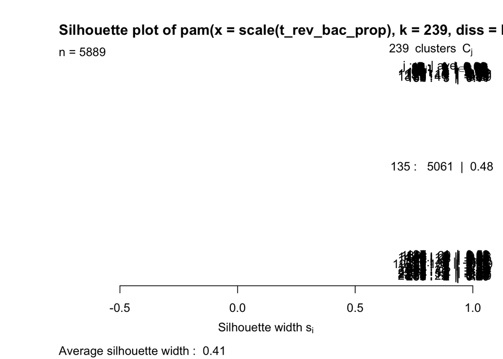

```r
plot(silhouette(t_pam_out))
```

```r
library(factoextra)
```